# RLVotosDep

Antonio Lúcio

28 de novembro de 2017

```r
knitr::opts_chunk$set(echo = TRUE, warning=FALSE, message=FALSE)
```

```r
library(dplyr)
library(readr)
library(knitr)
library(highcharter)
library(Amelia)
library(tidyr)
library(corrplot)
library(leaps)
library(ggplot2)
library(fBasics)
```

```r
eleicoes <- read.csv("eleicoes2014.csv", encoding = "latin1")
```

Após os dados serem carregados, foi observado que muitas células da tabela de dados estão vazias, o que prejudica o andamento do laboratório, assim precisamos corrigir. As colunas mais afetadas são recursos_de_outros_candidatos.comites, recursos_de_partidos, recursos_de_pessoas_físicas, recursos_de_pessoas_juridicas e recursos_proprios.

Antes de decidir como corrigir, vamos visualizar apenas os dados destas colunas:

```r
dadosComProblemas <- eleicoes %>% select(recursos_de_outros_candidatos.comites, recursos_de_partidos, recursos_de_pessoas_físicas, recursos_de_pessoas_juridicas, recursos_proprios)

summary(dadosComProblemas)
```

```
##  recursos_de_outros_candidatos.comites recursos_de_partidos
##  Min.   :      0.2                     Min.   :      0
##  1st Qu.:   1101.2                     1st Qu.:   2030
##  Median :   4217.5                     Median :   6325
##  Mean   :  32403.3                     Mean   : 194633
##  3rd Qu.:  19150.0                     3rd Qu.: 105957
##  Max.   :1788100.5                     Max.   :5769682
##  NA's   :1575                          NA's   :2286
##  recursos_de_pessoas_físicas recursos_de_pessoas_juridicas
##  Min.   :      0             Min.   :      1
##  1st Qu.:   1100             1st Qu.:   3000
##  Median :   4550             Median :  28086
##  Mean   :  39734             Mean   : 200014
##  3rd Qu.:  28358             3rd Qu.: 201947
##  Max.   :1826762             Max.   :3532069
##  NA's   :1148                NA's   :2778
##  recursos_proprios
##  Min.   :      0
##  1st Qu.:   1100
##  Median :   5019
##  Mean   :  44713
##  3rd Qu.:  22233
##  Max.   :3752000
##  NA's   :1860
```

Como podemos observar acima, existem muitos NA’s nas colunas (como já tinha sido dito) e há uma grande difereça da média para mediana nas colunas, ou seja, existem muitos outliers que terminam influenciando muito na média. Para solucionar o problema das células com NA’s, irei preenchê-las com a mediana(não utilizarei a média pelos problemas citados acima) da sua respectiva coluna.

```r
eleicoes$recursos_de_outros_candidatos.comites[is.na(eleicoes$recursos_de_outros_candidatos.comites)]<-median (eleicoes$recursos_de_outros_candidatos.comites, na.rm = TRUE)

eleicoes$recursos_proprios[is.na(eleicoes$recursos_proprios)]<-median (eleicoes$recursos_proprios, na.rm = TRUE)

eleicoes$recursos_de_pessoas_físicas[is.na(eleicoes$recursos_de_pessoas_físicas)]<-median (eleicoes$recursos_de_pessoas_físicas, na.rm = TRUE)

eleicoes$recursos_de_pessoas_juridicas[is.na(eleicoes$recursos_de_pessoas_juridicas)]<-median (eleicoes$recursos_de_pessoas_juridicas, na.rm = TRUE)

eleicoes$recursos_de_partidos[is.na(eleicoes$recursos_de_partidos)]<-median (eleicoes$recursos_de_partidos, na.rm = TRUE)
```

Bem, agora que o problema foi corrigido, vamos ao lab.

#### Um modelo de regressão múltipla com todas as variáveis é plausível para explicar a variação em y (número de votos)? Justifique sua resposta.

Para verificarmos se é plausível utilizar todas as variáveis, utilizaremos o p-valor. Se o p-valor for maior que 0,05 indica que a probabilidade da causalidade entre a variável e a quantidade de votos ser aleatória é grande, ou seja, não é ideal para predizer a quantidade de votos.

Porém, antes disso, precisamos ajustar algumas variáveis categóricas, as tornando numéricas e ainda excluir dos dados algumas informações que não nos ajudarão, como por exemplo sequencial do candidato, nome, número candidato, cargo.(que foram retirados por serem únicos) e setor econômico receita/despesa (por serem muitos níveis)

```r
#Retirados as colunas que não são necessárias
dadosFiltrados <- eleicoes %>% select(-nome, -sequencial_candidato, -numero_cadidato, -cargo, -setor_economico_receita, -setor_economico_despesa)

#Transformando variável sexo em numérica, onde Feminino=1 e Masculino=2
dadosFiltrados$sexo <- as.numeric(dadosFiltrados$sexo)

#Transformando variável grau (nível de estudo), onde:
#1 = Ensino Fundamental Completo ;   2 = Ens. Fund. Incomp.  ; 3 = Ens. Médio Comp.; 4 = Ens. Médio Incomp.
#5 = Lê e escreve ; 6 = Sup. Completo  ; 7 = Superior Incompleto.
dadosFiltrados$grau <- as.numeric(dadosFiltrados$grau)

#Transformando variável estado civil em numérica, onde:
#1= Casado ; 2= Divorciado(a) ; 3= Separado(a) judicialmente ; 4= Solteiro(a) ; 5 = Viúvo(a)
dadosFiltrados$estado_civil <-as.numeric(dadosFiltrados$estado_civil)

#1 = AC, 2 = AL, 3 = AM, 4 = AP, 5 = BA, 6 = CE, 7= DF, 8=ES, 9=GO, 10=MA, 11=MG, 12=MS, 13=MT,
#14=PA, 15=PB, 16=PE, 17=PI, 18=PR, 19=RJ, 20=RN, 21=RO, 22=RR, 23=RS, 24=SC, 25=SE, 26=SP,27=TO
dadosFiltrados$UF <-as.numeric(dadosFiltrados$UF)

#1=DEM, 2=PC do B, 3=PCB, 4=PCO, 5=PDT, 6=PEN, 7=PHS, 8=PMDB, 9 =PMN, 10=PP, 11=PPL, 12=PPS, 13=PR, 14=PRB, 15=PROS, #16=PRP, 17=PRTB, 18=PSB, 19=PSC, 20=PSD, 21=PSDB, 22=PSDC, 23=PSL, 24=PSOL, 25=PSTU, 26=PT, 27=PT do B, 28=PTB, #29=PTC, 30=PTN, 31=PV, 32=SD
dadosFiltrados$partido <-as.numeric(dadosFiltrados$partido)

dadosFiltradosCompletos <- dadosFiltrados
```

Agora que dispensamos as colunas que não ajudam a responder e transformamos as colunas que continham variáveis categóricas em numéricas, vamos calcular o p-valor das colunas com relação a coluna de votos.

```r
t.test (dadosFiltrados$UF,dadosFiltrados$votos)
```

```
##
##  Welch Two Sample t-test
##
## data:  dadosFiltrados$UF and dadosFiltrados$votos
## t = -24.534, df = 4151, p-value < 2.2e-16
## alternative hypothesis: true difference in means is not equal to 0
## 95 percent confidence interval:
##  -18619.50 -15863.93
## sample estimates:
##   mean of x   mean of y
##    16.77336 17258.48675
```

```r
t.test (dadosFiltrados$partido,dadosFiltrados$votos)
```

```
##
##  Welch Two Sample t-test
##
## data:  dadosFiltrados$partido and dadosFiltrados$votos
## t = -24.533, df = 4151, p-value < 2.2e-16
## alternative hypothesis: true difference in means is not equal to 0
## 95 percent confidence interval:
##  -18618.57 -15863.00
## sample estimates:
##   mean of x   mean of y
##    17.69918 17258.48675
```

```r
t.test (dadosFiltrados$quantidade_doacoes,dadosFiltrados$votos)
```

```
##
##  Welch Two Sample t-test
##
## data:  dadosFiltrados$quantidade_doacoes and dadosFiltrados$votos
## t = -24.525, df = 4151, p-value < 2.2e-16
## alternative hypothesis: true difference in means is not equal to 0
## 95 percent confidence interval:
##  -18612.71 -15857.14
## sample estimates:
##   mean of x   mean of y
##    23.56551 17258.48675
```

```r
t.test (dadosFiltrados$quantidade_doadores,dadosFiltrados$votos)
```

```
##
##  Welch Two Sample t-test
##
## data:  dadosFiltrados$quantidade_doadores and dadosFiltrados$votos
## t = -24.54, df = 4151, p-value < 2.2e-16
## alternative hypothesis: true difference in means is not equal to 0
## 95 percent confidence interval:
##  -18623.57 -15867.99
## sample estimates:
##   mean of x   mean of y
##    12.70665 17258.48675
```

```r
t.test (dadosFiltrados$total_receita,dadosFiltrados$votos)
```

```
##
##  Welch Two Sample t-test
##
## data:  dadosFiltrados$total_receita and dadosFiltrados$votos
## t = 21.22, df = 4193, p-value < 2.2e-16
## alternative hypothesis: true difference in means is not equal to 0
## 95 percent confidence interval:
##  190679.0 229499.9
## sample estimates:
## mean of x mean of y
## 227347.92  17258.49
```

```r
t.test (dadosFiltrados$media_receita,dadosFiltrados$votos)
```

```
##
##  Welch Two Sample t-test
##
## data:  dadosFiltrados$media_receita and dadosFiltrados$votos
## t = -15.044, df = 5049.7, p-value < 2.2e-16
## alternative hypothesis: true difference in means is not equal to 0
## 95 percent confidence interval:
##  -12587.510  -9685.068
## sample estimates:
## mean of x mean of y
##  6122.198 17258.487
```

```r
t.test (dadosFiltrados$recursos_de_outros_candidatos.comites,dadosFiltrados$votos)
```

```
##
##  Welch Two Sample t-test
##
## data:  dadosFiltrados$recursos_de_outros_candidatos.comites and dadosFiltrados$votos
## t = 2.8751, df = 6167.9, p-value = 0.004052
## alternative hypothesis: true difference in means is not equal to 0
## 95 percent confidence interval:
##  1416.810 7489.124
## sample estimates:
## mean of x mean of y
##  21711.45  17258.49
```

```r
t.test (dadosFiltrados$recursos_de_partidos,dadosFiltrados$votos)
```

```
##
##  Welch Two Sample t-test
##
## data:  dadosFiltrados$recursos_de_partidos and dadosFiltrados$votos
## t = 13.365, df = 4288, p-value < 2.2e-16
## alternative hypothesis: true difference in means is not equal to 0
## 95 percent confidence interval:
##  62885.90 84506.98
## sample estimates:
## mean of x mean of y
##  90954.93  17258.49
```

```r
t.test (dadosFiltrados$recursos_de_pessoas_físicas,dadosFiltrados$votos)
```

```
##
##  Welch Two Sample t-test
##
## data:  dadosFiltrados$recursos_de_pessoas_físicas and dadosFiltrados$votos
## t = 8.2132, df = 6158.4, p-value = 2.601e-16
## alternative hypothesis: true difference in means is not equal to 0
## 95 percent confidence interval:
##   9705.007 15790.287
## sample estimates:
## mean of x mean of y
##  30006.13  17258.49
```

```r
t.test (dadosFiltrados$recursos_de_pessoas_juridicas,dadosFiltrados$votos)
```

```
##
##  Welch Two Sample t-test
##
## data:  dadosFiltrados$recursos_de_pessoas_juridicas and dadosFiltrados$votos
## t = 17.169, df = 4422.9, p-value < 2.2e-16
## alternative hypothesis: true difference in means is not equal to 0
## 95 percent confidence interval:
##  59989.87 75455.74
## sample estimates:
## mean of x mean of y
##  84981.29  17258.49
```

```r
t.test (dadosFiltrados$recursos_proprios,dadosFiltrados$votos)
```

```
##
##  Welch Two Sample t-test
##
## data:  dadosFiltrados$recursos_proprios and dadosFiltrados$votos
## t = 4.2224, df = 5004.2, p-value = 2.46e-05
## alternative hypothesis: true difference in means is not equal to 0
## 95 percent confidence interval:
##   5181.704 14163.734
## sample estimates:
## mean of x mean of y
##  26931.21  17258.49
```

```r
t.test (dadosFiltrados$quantidade_despesas,dadosFiltrados$votos)
```

```
##
##  Welch Two Sample t-test
##
## data:  dadosFiltrados$quantidade_despesas and dadosFiltrados$votos
## t = -24.357, df = 4151.7, p-value < 2.2e-16
## alternative hypothesis: true difference in means is not equal to 0
## 95 percent confidence interval:
##  -18495.83 -15740.14
## sample estimates:
##  mean of x  mean of y
##   140.4986 17258.4868
```

```r
t.test (dadosFiltrados$quantidade_fornecedores,dadosFiltrados$votos)
```

```
##
##  Welch Two Sample t-test
##
## data:  dadosFiltrados$quantidade_fornecedores and dadosFiltrados$votos
## t = -24.459, df = 4151.2, p-value < 2.2e-16
## alternative hypothesis: true difference in means is not equal to 0
## 95 percent confidence interval:
##  -18566.99 -15811.38
## sample estimates:
##   mean of x   mean of y
##    69.29986 17258.48675
```

```r
t.test (dadosFiltrados$total_despesa,dadosFiltrados$votos)
```

```
##
##  Welch Two Sample t-test
##
## data:  dadosFiltrados$total_despesa and dadosFiltrados$votos
## t = 21.075, df = 4190.9, p-value < 2.2e-16
## alternative hypothesis: true difference in means is not equal to 0
## 95 percent confidence interval:
##  194207.5 234045.5
## sample estimates:
## mean of x mean of y
## 231385.00  17258.49
```

```r
t.test (dadosFiltrados$media_despesa,dadosFiltrados$votos)
```

```
##
##  Welch Two Sample t-test
##
## data:  dadosFiltrados$media_despesa and dadosFiltrados$votos
## t = -22.766, df = 4162.2, p-value < 2.2e-16
## alternative hypothesis: true difference in means is not equal to 0
## 95 percent confidence interval:
##  -17388.47 -14631.04
## sample estimates:
## mean of x mean of y
##  1248.732 17258.487
```

```r
t.test (dadosFiltrados$idade,dadosFiltrados$votos)
```

```
##
##  Welch Two Sample t-test
##
## data:  dadosFiltrados$idade and dadosFiltrados$votos
## t = -24.49, df = 4151, p-value < 2.2e-16
## alternative hypothesis: true difference in means is not equal to 0
## 95 percent confidence interval:
##  -18588.43 -15832.86
## sample estimates:
##   mean of x   mean of y
##    47.84658 17258.48675
```

```r
t.test (dadosFiltrados$sexo,dadosFiltrados$votos)
```

```
##
##  Welch Two Sample t-test
##
## data:  dadosFiltrados$sexo and dadosFiltrados$votos
## t = -24.556, df = 4151, p-value < 2.2e-16
## alternative hypothesis: true difference in means is not equal to 0
## 95 percent confidence interval:
##  -18634.55 -15878.98
## sample estimates:
##    mean of x    mean of y
##     1.723266 17258.486753
```

```r
t.test (dadosFiltrados$grau,dadosFiltrados$votos)
```

```
##
##  Welch Two Sample t-test
##
## data:  dadosFiltrados$grau and dadosFiltrados$votos
## t = -24.551, df = 4151, p-value < 2.2e-16
## alternative hypothesis: true difference in means is not equal to 0
## 95 percent confidence interval:
##  -18631.31 -15875.74
## sample estimates:
##    mean of x    mean of y
##     4.959538 17258.486753
```

```r
t.test (dadosFiltrados$estado_civil,dadosFiltrados$votos)
```

```
##
##  Welch Two Sample t-test
##
## data:  dadosFiltrados$estado_civil and dadosFiltrados$votos
## t = -24.555, df = 4151, p-value < 2.2e-16
## alternative hypothesis: true difference in means is not equal to 0
## 95 percent confidence interval:
##  -18634.21 -15878.64
## sample estimates:
##    mean of x    mean of y
##     2.060453 17258.486753
```

Como pudemos observar, todas as colunas restantes possuem um p-valor bem abaixo de 0.05, ou seja, a probabilidade da causalidade entre as demais variáveis e a quantidade de votos ser aleatória é muito baixa!

E finalmente respondendo a pergunta: Um modelo de regressão linear múltipla com todas as variáveis não é plausível, tendo em vista que exitem variáveis que são únicas nos dados e por isso não apresenta correlação com a variável alvo.

#### Todas as variáveis são úteis para o modelo de regressão? Há variáveis redudantes? Justifique sua resposta em ambos os casos.

Temos que selecionar apenas as melhores variáveis de predição e descartar as que não são interessantes, ou seja, as que nao predizem a quantidade de votos ou que são redundantes para o modelo. Para verificar as variáveis, vamos utilizar:

```r
corr = cor(dadosFiltrados[, 1:20])
round(corr, 2)
```

```
##                                          UF partido quantidade_doacoes
## UF                                     1.00    0.00               0.02
## partido                                0.00    1.00               0.03
## quantidade_doacoes                     0.02    0.03               1.00
## quantidade_doadores                    0.00    0.04               0.86
## total_receita                         -0.02   -0.04               0.60
## media_receita                         -0.09   -0.08               0.12
## recursos_de_outros_candidatos.comites  0.01   -0.05               0.36
## recursos_de_partidos                  -0.02   -0.06               0.40
## recursos_de_pessoas_físicas           -0.03    0.03               0.59
## recursos_de_pessoas_juridicas         -0.01    0.00               0.47
## recursos_proprios                     -0.03   -0.02               0.21
## votos                                 -0.01   -0.04               0.48
## quantidade_despesas                   -0.01   -0.02               0.58
## quantidade_fornecedores               -0.04   -0.01               0.50
## total_despesa                         -0.02   -0.04               0.60
## media_despesa                         -0.11   -0.07               0.14
## idade                                  0.01   -0.04               0.07
## sexo                                   0.00    0.00               0.14
## grau                                   0.00   -0.05               0.13
## estado_civil                          -0.02    0.02              -0.11
##                                       quantidade_doadores total_receita
## UF                                                   0.00         -0.02
## partido                                              0.04         -0.04
## quantidade_doacoes                                   0.86          0.60
## quantidade_doadores                                  1.00          0.46
## total_receita                                        0.46          1.00
## media_receita                                        0.09          0.60
## recursos_de_outros_candidatos.comites                0.20          0.42
## recursos_de_partidos                                 0.24          0.82
## recursos_de_pessoas_físicas                          0.63          0.57
## recursos_de_pessoas_juridicas                        0.42          0.80
## recursos_proprios                                    0.15          0.38
## votos                                                0.42          0.62
## quantidade_despesas                                  0.48          0.81
## quantidade_fornecedores                              0.44          0.72
## total_despesa                                        0.46          0.99
## media_despesa                                        0.13          0.37
## idade                                                0.06          0.10
## sexo                                                 0.12          0.14
```

[output cut: 197 more lines]

```
## media_receita                          0.14  0.13        -0.10
## recursos_de_outros_candidatos.comites  0.08  0.08        -0.04
## recursos_de_partidos                   0.10  0.11        -0.08
## recursos_de_pessoas_físicas            0.11  0.12        -0.10
## recursos_de_pessoas_juridicas          0.11  0.11        -0.08
## recursos_proprios                      0.05  0.05        -0.04
## votos                                  0.16  0.14        -0.12
## quantidade_despesas                    0.12  0.12        -0.09
## quantidade_fornecedores                0.09  0.10        -0.08
## total_despesa                          0.14  0.15        -0.11
## media_despesa                          0.12  0.11        -0.10
## idade                                  0.12 -0.05        -0.24
## sexo                                   1.00  0.05        -0.22
## grau                                   0.05  1.00        -0.04
## estado_civil                          -0.22 -0.04         1.00
```

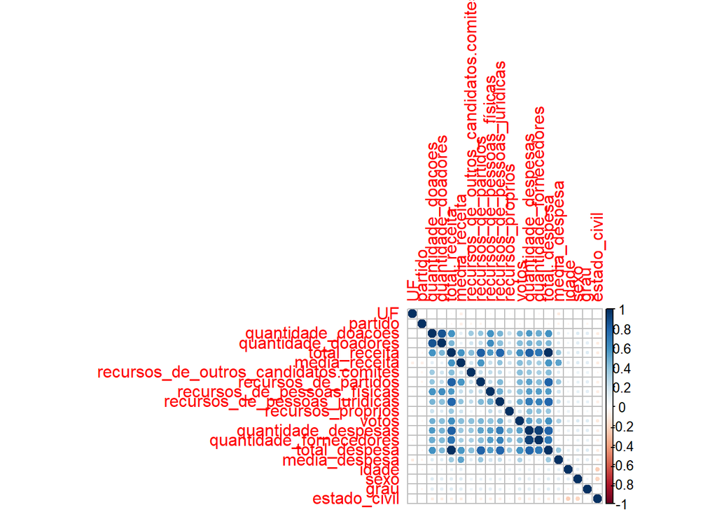

```r
corrplot(corr, method="circle")
```

O método corrplot gera correlações entre as variáveis. E como podemos ver, há variáveis com correlação muito forte, o que sugere redundância como o caso de total_depesa x total_receita = 0.99, quantidade_fornecedores x quantidade_despesas = 0.93, quantiade_doadores x quantidade_doacoes = 0.86 e recursos_partidos x total_receita = 0.82.

As variáveis total_despesa, quantidade_despesas serão retiradas.

```r
dadosFiltrados <- dadosFiltrados %>% select(-total_despesa, -quantidade_despesas)
```

Assim, respodendo a pergunta: Não, nem todas as variáveis são úteis pois há variáveis redundantes, como foi mostrado pela forte correlação entre elas.

#### No caso de haver variáveis pouco explicativas e/ou redudantes, construa um novo modelo sem essas variáveis e o compare ao modelo com todas as variáveis (e.g. em termos de R2 e RSE).

Para o modelo com todas as variáveis:

```r
modeloCompleto <- lm(formula = votos ~ ., dadosFiltradosCompletos, na.action = na.omit)

summary(modeloCompleto)
```

```
##
## Call:
## lm(formula = votos ~ ., data = dadosFiltradosCompletos, na.action = na.omit)
##
## Residuals:
##     Min      1Q  Median      3Q     Max
## -307668   -6644    -989    2480 1242280
##
## Coefficients:
##                                         Estimate Std. Error t value
## (Intercept)                           4744.43671 4286.93615   1.107
## UF                                      25.27685   67.92742   0.372
## partido                                  5.40504   58.26520   0.093
## quantidade_doacoes                     -21.25991   26.52462  -0.802
## quantidade_doadores                    260.74795   38.92201   6.699
## total_receita                            0.36013    0.03953   9.111
## media_receita                            0.38643    0.05147   7.508
## recursos_de_outros_candidatos.comites   -0.22881    0.03955  -5.785
## recursos_de_partidos                    -0.32342    0.03881  -8.333
## recursos_de_pessoas_físicas             -0.32081    0.04009  -8.003
## recursos_de_pessoas_juridicas           -0.31205    0.03880  -8.042
## recursos_proprios                       -0.33626    0.03907  -8.607
## quantidade_despesas                     48.43825    4.28102  11.315
## quantidade_fornecedores                -55.33477    6.16399  -8.977
## total_despesa                           -0.02761    0.00743  -3.716
## media_despesa                            2.02653    0.39608   5.116
## idade                                   32.78024   45.06215   0.727
## sexo                                  2005.74480 1182.09863   1.697
## grau                                   299.36781  295.57537   1.013
## estado_civil                          -532.13468  389.84193  -1.365
##                                       Pr(>|t|)
## (Intercept)                           0.268480
## UF                                    0.709826
## partido                               0.926094
## quantidade_doacoes                    0.422879
## quantidade_doadores                   2.38e-11 ***
## total_receita                          < 2e-16 ***
## media_receita                         7.32e-14 ***
## recursos_de_outros_candidatos.comites 7.78e-09 ***
## recursos_de_partidos                   < 2e-16 ***
## recursos_de_pessoas_físicas           1.57e-15 ***
## recursos_de_pessoas_juridicas         1.14e-15 ***
## recursos_proprios                      < 2e-16 ***
## quantidade_despesas                    < 2e-16 ***
## quantidade_fornecedores                < 2e-16 ***
## total_despesa                         0.000205 ***
## media_despesa                         3.25e-07 ***
## idade                                 0.466995
## sexo                                  0.089816 .
## grau                                  0.311200
## estado_civil                          0.172327
## ---
## Signif. codes:  0 '***' 0.001 '**' 0.01 '*' 0.05 '.' 0.1 ' ' 1
##
## Residual standard error: 32480 on 4132 degrees of freedom
## Multiple R-squared:  0.4879, Adjusted R-squared:  0.4856
## F-statistic: 207.2 on 19 and 4132 DF,  p-value: < 2.2e-16
```

Temos que: RSE = 32.480 e R² ajustado = 0.4856 __

Já para o modelo com o número de variáveis reduzidas:

```r
modeloFiltrado <- lm(formula = votos ~ ., dadosFiltrados, na.action = na.omit)

summary(modeloFiltrado)
```

```
##
## Call:
## lm(formula = votos ~ ., data = dadosFiltrados, na.action = na.omit)
##
## Residuals:
##     Min      1Q  Median      3Q     Max
## -216058   -6841   -1193    2307 1292214
##
## Coefficients:
##                                         Estimate Std. Error t value
## (Intercept)                           6399.01461 4354.52911   1.470
## UF                                      53.77177   68.96626   0.780
## partido                                -11.74145   59.19864  -0.198
## quantidade_doacoes                      20.69824   26.41579   0.784
## quantidade_doadores                    236.29814   39.33504   6.007
## total_receita                            0.38390    0.03922   9.788
## media_receita                            0.40298    0.05228   7.708
## recursos_de_outros_candidatos.comites   -0.26732    0.04005  -6.675
## recursos_de_partidos                    -0.36638    0.03925  -9.334
## recursos_de_pessoas_físicas             -0.37253    0.04047  -9.205
## recursos_de_pessoas_juridicas           -0.35574    0.03925  -9.063
## recursos_proprios                       -0.37456    0.03956  -9.468
## quantidade_fornecedores                  2.68071    3.55143   0.755
## media_despesa                            1.01181    0.39248   2.578
## idade                                   28.57162   45.79674   0.624
## sexo                                  2242.97323 1201.22779   1.867
## grau                                   389.98071  300.29166   1.299
## estado_civil                          -514.89620  396.20876  -1.300
##                                       Pr(>|t|)
## (Intercept)                            0.14177
## UF                                     0.43562
## partido                                0.84279
## quantidade_doacoes                     0.43335
## quantidade_doadores                   2.05e-09 ***
## total_receita                          < 2e-16 ***
## media_receita                         1.59e-14 ***
## recursos_de_outros_candidatos.comites 2.80e-11 ***
## recursos_de_partidos                   < 2e-16 ***
## recursos_de_pessoas_físicas            < 2e-16 ***
## recursos_de_pessoas_juridicas          < 2e-16 ***
## recursos_proprios                      < 2e-16 ***
## quantidade_fornecedores                0.45040
## media_despesa                          0.00997 **
## idade                                  0.53274
## sexo                                   0.06194 .
## grau                                   0.19413
## estado_civil                           0.19383
## ---
## Signif. codes:  0 '***' 0.001 '**' 0.01 '*' 0.05 '.' 0.1 ' ' 1
##
## Residual standard error: 33010 on 4134 degrees of freedom
## Multiple R-squared:  0.4708, Adjusted R-squared:  0.4686
## F-statistic: 216.4 on 17 and 4134 DF,  p-value: < 2.2e-16
```

Temos que: RSE = 33.010 e R² ajustado = 0.4686

Ou seja, do modelo completo para o modelo com variáveis reduzidas o erro aumentou e o R² ajustado caiu. Ou seja, o novo modelo está mais generalista.

#### Analise plots de resíduos e verifique se há tendências nos erros.

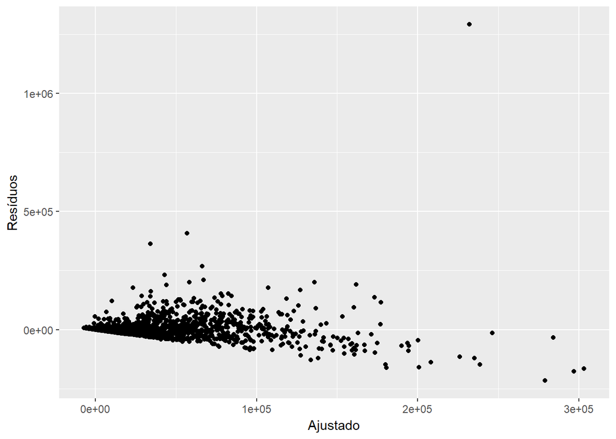

```r
ggplot(modeloFiltrado, aes(x = .fitted, y = .resid)) +
  geom_point() +
  xlab("Ajustado") +
  ylab("Resíduos")
```

Observando o gráfico, percebemos que os resíduos possuem um padrão, mostrando que não que o modelo ainda não é o ideal.

#### Quais variáveis conseguem explicar melhor o número de votos?

para esta tarefa, utilizaremos uma função do pacote do R chamado leaps que procura o melhor subconjuntos entre as variáveis x que predizem y.

```r
conjuntos <-
    regsubsets(votos ~ .,
               data = dadosFiltrados,
               nbest = 1,
               nvmax = NULL,
               force.in = NULL, force.out = NULL,
               method = "exhaustive",
               really.big = T)

summaryConjuntos <- summary(conjuntos)
summaryConjuntos
```

```
## Subset selection object
## Call: regsubsets.formula(votos ~ ., data = dadosFiltrados, nbest = 1,
##     nvmax = NULL, force.in = NULL, force.out = NULL, method = "exhaustive",
##     really.big = T)
## 17 Variables  (and intercept)
##                                       Forced in Forced out
## UF                                        FALSE      FALSE
## partido                                   FALSE      FALSE
## quantidade_doacoes                        FALSE      FALSE
## quantidade_doadores                       FALSE      FALSE
## total_receita                             FALSE      FALSE
## media_receita                             FALSE      FALSE
## recursos_de_outros_candidatos.comites     FALSE      FALSE
## recursos_de_partidos                      FALSE      FALSE
## recursos_de_pessoas_físicas               FALSE      FALSE
```

[output cut: 118 more lines]

Agora precisamos saber qual o melhor modelo entre os subconjuntos e o R² ajustado. (Lembrando que o R² ajustado indica, em percentagem, o quanto o modelo consegue explicar os valores observados).

```r
escolhaModelo <- which.max(summaryConjuntos$adjr2)
escolhaModelo
```

```
## [1] 12
```

```r
respostas <- summaryConjuntos$which[escolhaModelo,]
dfResposta <- data.frame(respostas)
dfResposta
```

```
##                                       respostas
## (Intercept)                                TRUE
## UF                                        FALSE
## partido                                   FALSE
## quantidade_doacoes                        FALSE
## quantidade_doadores                        TRUE
## total_receita                              TRUE
## media_receita                              TRUE
## recursos_de_outros_candidatos.comites      TRUE
## recursos_de_partidos                       TRUE
## recursos_de_pessoas_físicas                TRUE
## recursos_de_pessoas_juridicas              TRUE
## recursos_proprios                          TRUE
## quantidade_fornecedores                   FALSE
## media_despesa                              TRUE
## idade                                     FALSE
## sexo                                       TRUE
## grau                                       TRUE
## estado_civil                               TRUE
```

Como podemos ver acima, nem todas as variáveis do modelo são boas para fazer a predição. No caso, as variáveis que melhor explicam(utilizando leaps para encontrar o melhor subconjunto associado ao R² ajustado) o número de votos são: